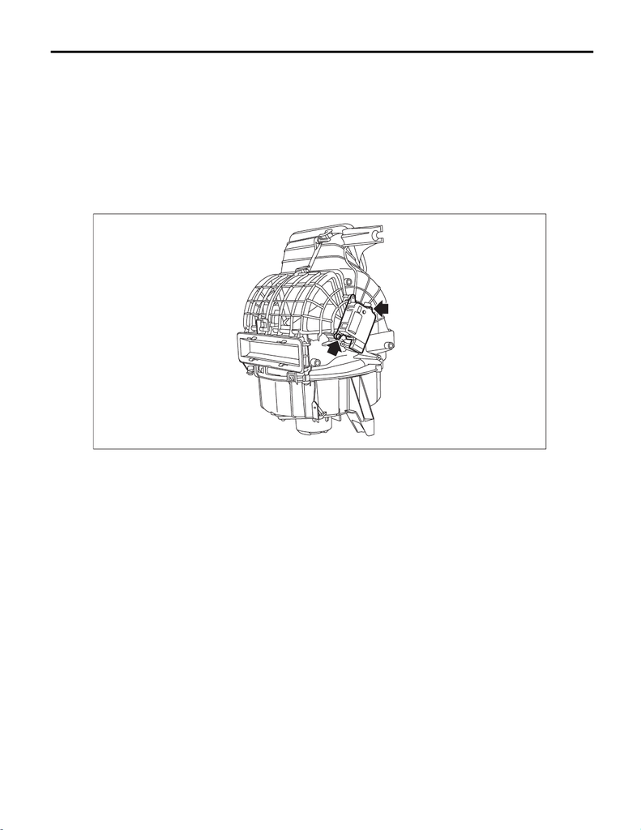

AC-84

FRESH/RECIRC Door Actuator

HVAC SYSTEM (HEATER, VENTILATOR AND A/C)

25.FRESH/RECIRC Door Actuator

A: REMOVAL

1) Disconnect the ground cable from battery. <Ref. to NT-5, BATTERY, NOTE, Note.>

NOTE:

For models other than STI model, disconnect the ground terminal from battery sensor.

2) Remove the glove box. <Ref. to EI-63, REMOVAL, Glove Box.>

3) Remove the engine control module (ECM). (STI model) <Ref. to FU(STI)-56, REMOVAL, Engine Control

Module (ECM).>

4) Remove the blower motor unit assembly. <Ref. to AC-35, REMOVAL, Blower Motor Unit Assembly.>

5) Remove the screws and detach the motor - actuator blower.

B: INSTALLATION

CAUTION:

After installing the grille assembly - ventilation RH, check that the air vent grille of the grille assembly -

ventilation RH is inserted correctly into the air vent duct.

Tightening torque:

7.5 N·m (0.8 kgf-m, 5.5 ft-lb)

3) Install the engine control module (ECM). (STI model) <Ref. to FU(STI)-56, INSTALLATION, Engine Con-

trol Module (ECM).>

4) Install the glove box.

5) Connect the battery ground terminal. <Ref. to NT-5, BATTERY, NOTE, Note.>

NOTE:

For models other than STI model, connect the ground terminal to battery sensor.

AC-02737

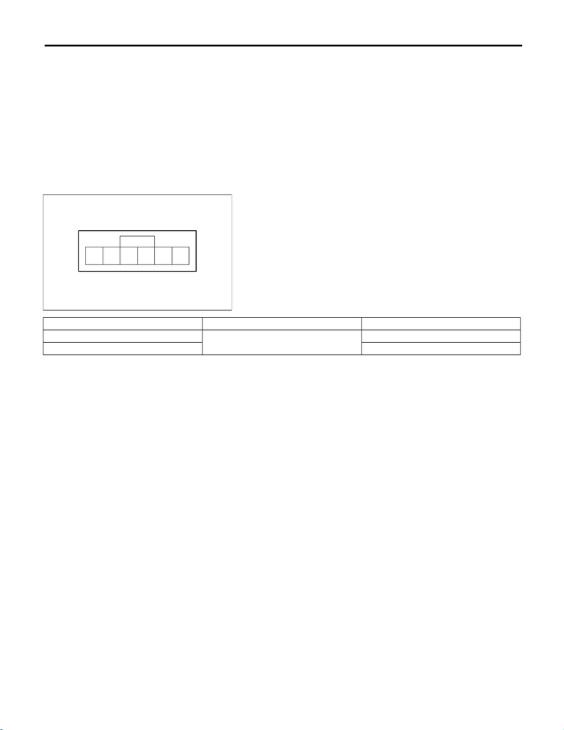

AC-85

FRESH/RECIRC Door Actuator

HVAC SYSTEM (HEATER, VENTILATOR AND A/C)

C: INSPECTION

1. CHECK LINK

1) Visually check the operation range of the link, and remove the foreign material if any.

2) Operate the FRESH/RECIRC switch to check that the link operates normally.

3) If it does not operate normally as the result of inspection, check the motor - actuator blower.

2. CHECK ACTUATOR

1) Check the actuator operation when battery voltage is applied between the connector terminals.

CAUTION:

Disconnect the battery immediately after the actuator stops operation. Otherwise, the motor may be

damaged.

2) If it does not operate normally as the result of inspection, replace the motor - actuator blower.

AC-03546

13 25 4

6

Terminal No. Inspection conditions Operating position

1 (+) — 2 (–)

Apply battery voltage.

RECIRC

2 (+) — 1 (–) FRESH